[figure not shown]

OD(diag)-4

General Description

OCCUPANT DETECTION SYSTEM (DIAGNOSTICS)

3. General Description

A: CAUTION

1) The occupant detection system (passenger seat only) control module and the occupant detection sensor

are fixed to the seat cushion frame. Never remove the occupant detection control module or the occupant de-

tection sensor from the seat cushion frame.

2) Do not replace the seat cushion pad by itself. Always replace the seat cushion pad and frame assembly

as a set. The seat cushion pad and cushion frame are adjusted as a set at the time of manufacture. If cushion

pads and cushion frames are combined from those of other vehicles or other sets, the occupant detection

system may not operate properly.

3) If the seat cushion cover is removed, make sure to replace the hang wire on the seat cushion side with a

new wire.

4) Never connect the battery in reverse polarity. Occupant detection system may be destroyed instantly.

5) Do not disconnect the battery terminals while the engine is running. A large counter electromotive force

will be generated in the generator, and this voltage may damage electronic parts such as occupant detection

control module.

6) Before disconnecting the connectors of each sensor and control module, be sure to turn the ignition switch

to OFF and wait for 60 seconds or more. Occupant detection control module may be damaged.

7) Every occupant detection system-related part is a precision part. Do not drop them.

CAUTION:

• Do not use electrical test equipment on wiring harness and connector circuits of the airbag sys-

tem.

• Be careful not to damage the airbag system wiring harness when servicing the occupant detection

system.

• Refer to CAUTION in Airbag System when repairing the occupant detection system. <Ref. to AB-9,

CAUTION, General Description.>

B: INSPECTION

Measure the battery voltage and check electrolyte.

Standard voltage:

12 V

Specific gravity:

1.260 or more

Fluid level:

Between the upper level and lower level

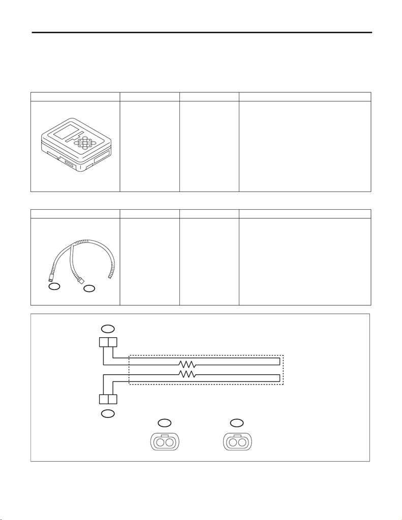

OD(diag)-5

General Description

OCCUPANT DETECTION SYSTEM (DIAGNOSTICS)

C: PREPARATION TOOL

CAUTION:

To measure the voltage and resistance of airbag system and occupant detection system compo-

nents, be sure to use the specified test harness.

1. SPECIAL TOOL

• TEST HARNESS Y

ILLUSTRATION TOOL NUMBER DESCRIPTION REMARKS

1B022XU0 SUBARU SELECT

MONITOR III KIT

Used for troubleshooting the electrical system.

ILLUSTRATION TOOL NUMBER DESCRIPTION REMARKS

98299AG040 TEST HARNESS Y Used for troubleshooting seat belt buckle switch.

ST1B022XU0

ST98299AG040

AB-01069

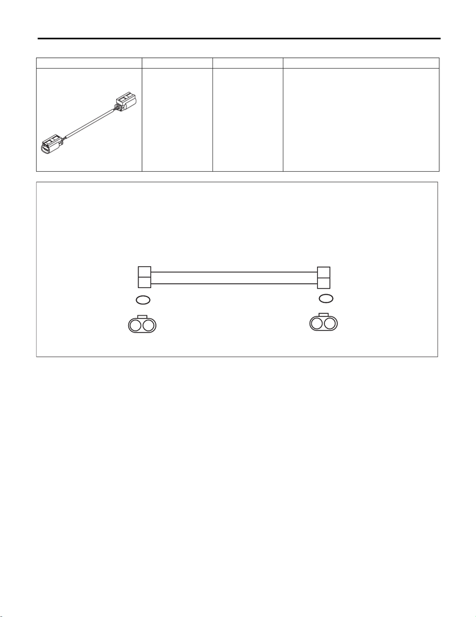

OD(diag)-6

General Description

OCCUPANT DETECTION SYSTEM (DIAGNOSTICS)

• TEST HARNESS AE

ILLUSTRATION TOOL NUMBER DESCRIPTION REMARKS

98299XA030 TEST HARNESS

AE

TEST HARNESS Y adapter harness

Used for troubleshooting seat belt buckle switch.

ST98299XA030

OD-00026

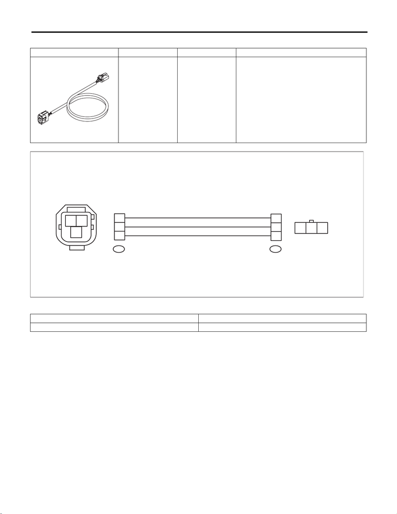

OD(diag)-7

General Description

OCCUPANT DETECTION SYSTEM (DIAGNOSTICS)

• TEST HARNESS AP

2. GENERAL TOOL

ILLUSTRATION TOOL NUMBER DESCRIPTION REMARKS

98299FJ030 TEST HARNESS

AP

Used when measuring voltage and resistance of

occupant detection system.

TOOL NAME REMARKS

Circuit tester Used for measuring resistance, voltage and current.

ST98299FJ030

AB-02734